# image_captioning

## Loading libraries

```python
# file, folder manipulation, and misc imports
import os
import glob
import string
import pickle
from time import time

# array processing
import numpy as np
from numpy import array
import pandas as  pd

#visualization
import matplotlib.pyplot as plt
from IPython.display import Image, display
from PIL import Image

# keras imports
from keras import Input, layers
from keras import optimizers
from keras.preprocessing import image
from keras.preprocessing import sequence
from keras.preprocessing.text import Tokenizer
from keras.preprocessing.sequence import pad_sequences

from keras.models import Model
from keras.models import Sequential

from keras.layers.merge import add
from keras.layers import LSTM, Embedding, TimeDistributed, Dense, RepeatVector,Activation, Flatten, Reshape, concatenate, Dropout, BatchNormalization

from keras.optimizers import Adam, RMSprop

from keras.applications.inception_v3 import InceptionV3
from keras.applications.inception_v3 import preprocess_input

from keras.utils import to_categorical

#magic functions
%matplotlib inline
```

## Defining some useful functions

```python
def load_doc(filename):
    """To load the descriptions"""
    with open(filename, 'r') as f:
        text = f.read()
    return text
```

```python
#path to the file "Flickr8k.token.txt" on your system
filename = "Flickr8k.token.txt"
doc = load_doc(filename)
```

```python
doc[0:100]
```

```
'1000268201_693b08cb0e.jpg#0\tA child in a pink dress is climbing up a set of stairs in an entry way .'
```

Now, we create a dictionary named “descriptions” which contains the name of the image (without the .jpg extension) as keys and a list of the 5 captions for the corresponding image as values.

```python
def load_descriptions(doc):
    """This fucntion is used to load the description files"""
    mapping = dict()
    # process lines
    for line in doc.split('\n'):
        # split line by white space
        tokens = line.split()
        if len(line) < 2:
            continue
        # take the first token as the image id, the rest as the description
        image_id, image_desc = tokens[0], tokens[1:]
        # extract filename from image id
        image_id = image_id.split('.')[0]
        # convert description tokens back to string
        image_desc = ' '.join(image_desc)
        # create the list if needed
        if image_id not in mapping:
            mapping[image_id] = list()
        # store description
        mapping[image_id].append(image_desc)
    return mapping

# parse descriptions
descriptions = load_descriptions(doc)
print('Loaded {} descriptions'.format(len(descriptions)))
```

```
Loaded 8092 descriptions
```

## Let us take a look at some image descriptions

```
1000268201_693b08cb0e
```

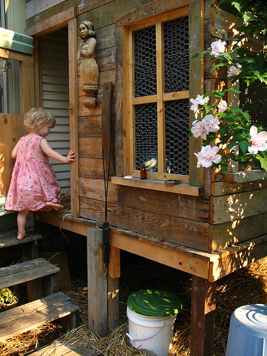

```
['A child in a pink dress is climbing up a set of stairs in an entry way .', 'A girl going into a wooden building .', 'A little girl climbing into a wooden playhouse .', 'A little girl climbing the stairs to her playhouse .', 'A little girl in a pink dress going into a wooden cabin .']


1001773457_577c3a7d70
```

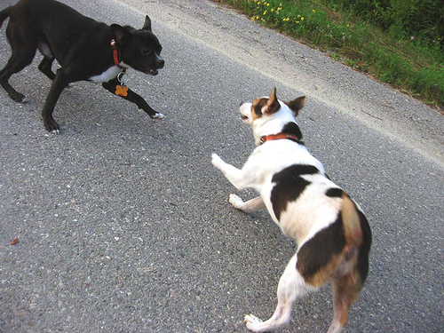

[output not shown]

```python
for i in list(descriptions.keys())[:2]:
    print(i)
    display(Image.open("Flickr8k_Dataset/{}.jpg".format(i)))
    print(descriptions[i])
    print("\n")
```

As you can see, each image has multiple descriptions, 5 to be precise, we will first clean the descriptions

```python
def clean_descriptions(descriptions):
    """This function is used to clean the descriptions , removing punctuations, taking only aplha numeric values
     converting to lower case, etc"""
    table = str.maketrans('', '', string.punctuation) # load punctuations
    for key, desc_list in descriptions.items():
        for i in range(len(desc_list)):
            desc = desc_list[i]
            desc = desc.split() # toknize the sentences
            desc = [word.lower() for word in desc] # convert to lower case
            desc = [w.translate(table) for w in desc] # removing punctuation
            desc = [word for word in desc if len(word)>1]# remove hanging 's' and 'a'
            desc = [word for word in desc if word.isalpha()]
            desc_list[i] =  ' '.join(desc) # reconstructing the sentence
    descriptions[key] = desc_list
    return descriptions

descriptions = clean_descriptions(descriptions)
```

Verify if all the descriptions were retrieved

```python
len(descriptions)
```

```
8092
```

### Extract the vocabulary from all the descriptions available

```python
def to_vocabulary(descriptions):
    all_desc = set()
    for key in descriptions.keys():
        [all_desc.update(d.split()) for d in descriptions[key]]
    return all_desc

# extract vocab
vocabulary = to_vocabulary(descriptions)
print('Vocabulary Size: {}'.format(len(vocabulary)))
```

```
Vocabulary Size: 8763
```

### Save the processed descriptions to a file

```python
def save_descriptions(descriptions, filename):
    lines = list()
    for key, desc_list in descriptions.items():
        for desc in desc_list:
            lines.append(key + ' ' + desc)
    data = '\n'.join(lines)
    with open(filename,'w') as f:
        f.write(data)

save_descriptions(descriptions, 'descriptions.txt')
```

## Load the file names for the images

```python
def load_set(filename):
    doc = load_doc(filename)
    dataset = list()
    for line in doc.split('\n'):
        # skip empty lines
        if len(line) < 1:
            continue
        identifier = line.split('.')[0]
        dataset.append(identifier)
    return set(dataset)
# load training dataset (6K images are present in train set)
filename = 'Flickr_8k.trainImages.txt'
train = load_set(filename)
print('Number of images in the dataset {}'.format(len(train)))
```

```
Number of images in the dataset 6000
```

```python
# Path to the images
images = 'Flicker8k_Dataset/'
# Create a list of all image names in the directory
img = glob.glob(images + '*.jpg')
```

```python
# Below file conatains the names of images to be used in train data
train_images_file = 'Flickr_8k.trainImages.txt'
# Read the train image names in a set
train_images = set(open(train_images_file, 'r').read().strip().split('\n'))
# Create a list of all the training images
train_img = []
for i in img:
    if i[len(images):] in train_images: # Check if the image belongs to training set
        train_img.append(i) # Add it to the list of train images
```

```python
# Below file conatains the names of images to be used in test data
test_images_file = 'Flickr_8k.testImages.txt'
# Read the validation image names in a set# Read the test image names in a set
test_images = set(open(test_images_file, 'r').read().strip().split('\n'))

# Create a list of all the test images with their full path names
test_img = []

for i in img:
    if i[len(images):] in test_images: # Check if the image belongs to testing set
        test_img.append(i)
```

### Load the previously written clean descriptions

```python
def load_clean_descriptions(filename, dataset):
    doc = load_doc(filename)
    descriptions = dict()
    for line in doc.split('\n'):
        tokens = line.split()
        image_id, image_desc = tokens[0], tokens[1:]
        if image_id in dataset:
            if image_id not in descriptions:
                descriptions[image_id] = list()
            # wrap description in with start and end seq
            desc = 'startseq ' + ' '.join(image_desc) + ' endseq'
            # store
            descriptions[image_id].append(desc)
    return descriptions

# descriptions
train_descriptions = load_clean_descriptions('descriptions.txt', train)
print('Descriptions: train=%d' % len(train_descriptions))
```

```
Descriptions: train=6000
```

## Data Preprocessing — Images

```python
def preprocess(image_path):
    """Preprocess the images for using transfer learning"""
    img = image.load_img(image_path, target_size=(299, 299))
    # Convert PIL image to numpy array of 3-dimensions
    x = image.img_to_array(img)
    # Add one more dimension
    x = np.expand_dims(x, axis=0)
    # preprocess the images using preprocess_input() from inception module
    x = preprocess_input(x)
    return x
```

```python
# Load the inception v3 model weights
# Note: The weights will be downloaded the first time
model = InceptionV3(weights='imagenet')
```

```python
# We will not be using the last 2 layers of the vggnet/
model_new = Model(model.input, model.layers[-2].output)
```

```python
def encode(image):
    image = preprocess(image) # preprocess the image
    feature_vec = model_new.predict(image)
    feature_vec = np.reshape(feature_vec, feature_vec.shape[1]) # reshape from (1, 2048) to (2048, )
    return feature_vec
```

```python
# encode all the train images
# This will take a while on CPU - Execute this only once
start = time()
encoding_train = {}
for img in train_img:
    encoding_train[img[len(images):]] = encode(img)
print("Time taken in seconds =", time()-start)
```

```python
# Save the bottleneck train features to disk
with open("pickle_files/encoded_train_images.pkl", "wb") as encoded_pickle:
    pickle.dump(encoding_train, encoded_pickle, protocol=2)
```

```python
# encode all the test images - Execute this only once
start = time()
encoding_test = {}
for img in test_img:
    encoding_test[img[len(images):]] = encode(img)
print("Time taken in seconds =", time()-start)
```

```python
# Save the bottleneck test features to disk
with open("pickle_files/encoded_test_images.pkl", "wb") as encoded_pickle:
    pickle.dump(encoding_test, encoded_pickle, protocol=2)
```

```python
with open("pickle_files/encoded_train_images.pkl", "rb") as p:
    encoding_train = pickle.load(p)
```

```python
with open("pickle_files/encoded_test_images.pkl", "rb") as p:
    encoding_test = pickle.load(p)
```

## Data Preprocessing — Captions

```python
train_features = load(open("pickle_files/encoded_train_images.pkl", "rb"))
print('Photos: train=%d' % len(train_features))
```

```
Photos: train=6000
```

```python
# Create a list of all the training captions
all_train_captions = []
for key, val in train_descriptions.items():
    for cap in val:
        all_train_captions.append(cap)
len(all_train_captions)
```

```
30000
```

```python
# Consider only words which occur at least 10 times in the corpus
word_count_threshold = 10
word_counts = {}
nsents = 0
for sent in all_train_captions:
    nsents += 1
    for w in sent.split(' '):
        word_counts[w] = word_counts.get(w, 0) + 1

vocab = [w for w in word_counts if word_counts[w] >= word_count_threshold]
print('preprocessed words %d -> %d' % (len(word_counts), len(vocab)))
```

```
preprocessed words 7578 -> 1651
```

```python
ixtoword = {}
wordtoix = {}
ix = 1 # 0 is used for padding
for w in vocab:
    wordtoix[w] = ix
    ixtoword[ix] = w
    ix += 1
```

```python
vocab_size = len(ixtoword) + 1
vocab_size
```

```
1652
```

```python
def to_lines(descriptions):
    """generate a list of descriptions"""
    all_desc = list()
    for key in descriptions.keys():
        [all_desc.append(d) for d in descriptions[key]]
    return all_desc

def max_length(descriptions):
    """Find the max length of the descriptions"""
    lines = to_lines(descriptions)
    return max(len(d.split()) for d in lines)

max_length = max_length(train_descriptions)
print('Max description length: {}'.format(max_length))
```

```
Max description length: 34
```

## Data Preparation using Generator Function

[figure not shown]

It must be noted that, one image+caption is not a single data point but are multiple data points depending on the length of the caption. Similarly if we consider both the images and their captions, our training data matrix will then look as follows:

[figure not shown]

We must now understand that in every data point, it’s not just the image which goes as input to the system, but also, a partial caption which helps to predict the next word in the sequence.Since we are processing sequences, we will employ a Recurrent Neural Network to read these partial captions (more on this later). However, we have already discussed that we are not going to pass the actual English text of the caption, rather we are going to pass the sequence of indices where each index represents a unique word. Since we have already created an index for each word, let’s now replace the words with their indices and understand how the data matrix will look like:

[figure not shown]

Since we would be doing batch processing (explained later), we need to make sure that each sequence is of equal length. Hence we need to append 0’s (zero padding) at the end of each sequence. But how many zeros should we append in each sequence? Well, this is the reason we had calculated the maximum length of a caption, which is 34 (if you remember). So we will append those many number of zeros which will lead to every sequence having a length of 34. The data matrix will then look as follows:

[figure not shown]

Need for a Data Generator: I hope this gives you a good sense as to how we can prepare the dataset for this problem. However, there is a big catch in this. In the above example, I have only considered 2 images and captions which have lead to 15 data points. However, in our actual training dataset we have 6000 images, each having 5 captions. This makes a total of 30000 images and captions. Even if we assume that each caption on an average is just 7 words long, it will lead to a total of 30000*7 i.e. 210000 data points. Compute the size of the data matrix: Data Matrix Size of the data matrix = n*m Where n-> number of data points (assumed as 210000) And m-> length of each data point Clearly m= Length of image vector(2048) + Length of partial caption(x). m = 2048 + x But what is the value of x? Well you might think it is 34, but no wait, it’s wrong. Every word (or index) will be mapped (embedded) to higher dimensional space through one of the word embedding techniques. Later, during the model building stage, we will see that each word/index is mapped to a 200-long vector using a pre-trained GLOVE word embedding model. Now each sequence contains 34 indices, where each index is a vector of length 200. Therefore x = 34*200 = 6800 Hence, m = 2048 + 6800 = 8848. Finally, size of data matrix= 210000 * 8848= 1858080000 values. Now even if we assume that one block takes 2 byte, then, to store this data matrix, we will require more than 3 GB of main memory. This is pretty huge requirement and even if we are able to manage to load this much data into the RAM, it will make the system very slow. For this reason we use data generators a lot in Deep Learning. Data Generators are a functionality which is natively implemented in Python. The ImageDataGenerator class provided by the Keras API is nothing but an implementation of generator function in Python.

```python
# data generator, intended to be used in a call to model.fit_generator()
def data_generator(descriptions, photos, wordtoix, max_length, num_photos_per_batch):
    X1, X2, y = list(), list(), list()
    n=0
    # loop for ever over images
    while 1:
        for key, desc_list in descriptions.items():
            n+=1
            # retrieve the photo feature
            photo = photos[key+'.jpg']
            for desc in desc_list:
                # encode the sequence
                seq = [wordtoix[word] for word in desc.split(' ') if word in wordtoix]
                # split one sequence into multiple X, y pairs
                for i in range(1, len(seq)):
                    # split into input and output pair
                    in_seq, out_seq = seq[:i], seq[i]
                    # pad input sequence
                    in_seq = pad_sequences([in_seq], maxlen=max_length)[0]
                    # encode output sequence
                    out_seq = to_categorical([out_seq], num_classes=vocab_size)[0]
                    # store
                    X1.append(photo)
                    X2.append(in_seq)
                    y.append(out_seq)
            # yield the batch data
            if n==num_photos_per_batch:
                yield [[array(X1), array(X2)], array(y)]
                X1, X2, y = list(), list(), list()
                n=0
```

## Word Embeddings

As already stated above, we will map the every word (index) to a 200-long vector and for this purpose, we will use a pre-trained GLOVE Model:

```python
# Load Glove vectors
glove_dir = 'glove/'
embeddings_index = {} # empty dictionary
f = open(os.path.join(glove_dir, 'glove.6B.200d.txt'), encoding="utf-8")

for line in f:
    values = line.split()
    word = values[0]
    coefs = np.asarray(values[1:], dtype='float32')
    embeddings_index[word] = coefs
f.close()
print('Found %s word vectors.' % len(embeddings_index))
```

```
Found 400000 word vectors.
```

```python
embedding_dim = 200

# Get 200-dim dense vector for each of the 10000 words in out vocabulary
embedding_matrix = np.zeros((vocab_size, embedding_dim))

for word, i in wordtoix.items():
    #if i < max_words:
    embedding_vector = embeddings_index.get(word)
    if embedding_vector is not None:
        # Words not found in the embedding index will be all zeros
        embedding_matrix[i] = embedding_vector
```

```python
embedding_matrix.shape
```

```
(1652, 200)
```

## Model Architecture

[figure not shown]

```python
# vocab_size * embedding_dim
```

```python
inputs1 = Input(shape=(2048,))
fe1 = Dropout(0.5)(inputs1)
fe2 = Dense(256, activation='relu')(fe1)
inputs2 = Input(shape=(max_length,))
se1 = Embedding(vocab_size, embedding_dim, mask_zero=True)(inputs2)
se2 = Dropout(0.5)(se1)
se3 = LSTM(256)(se2)
decoder1 = add([fe2, se3])
decoder2 = Dense(256, activation='relu')(decoder1)
outputs = Dense(vocab_size, activation='softmax')(decoder2)
model = Model(inputs=[inputs1, inputs2], outputs=outputs)
```

```python
model.summary()
```

```
__________________________________________________________________________________________________
Layer (type)                    Output Shape         Param #     Connected to
==================================================================================================
input_9 (InputLayer)            (None, 34)           0
__________________________________________________________________________________________________
input_8 (InputLayer)            (None, 2048)         0
__________________________________________________________________________________________________
embedding_3 (Embedding)         (None, 34, 200)      330400      input_9[0][0]
__________________________________________________________________________________________________
dropout_5 (Dropout)             (None, 2048)         0           input_8[0][0]
__________________________________________________________________________________________________
dropout_6 (Dropout)             (None, 34, 200)      0           embedding_3[0][0]
__________________________________________________________________________________________________
dense_7 (Dense)                 (None, 256)          524544      dropout_5[0][0]
__________________________________________________________________________________________________
lstm_3 (LSTM)                   (None, 256)          467968      dropout_6[0][0]
__________________________________________________________________________________________________
add_3 (Add)                     (None, 256)          0           dense_7[0][0]
                                                                 lstm_3[0][0]
__________________________________________________________________________________________________
dense_8 (Dense)                 (None, 256)          65792       add_3[0][0]
__________________________________________________________________________________________________
dense_9 (Dense)                 (None, 1652)         424564      dense_8[0][0]
==================================================================================================
Total params: 1,813,268
Trainable params: 1,813,268
Non-trainable params: 0
__________________________________________________________________________________________________
```

[figure not shown]

Recall that we had created an embedding matrix from a pre-trained Glove model which we need to include in the model before starting the training:

```python
model.layers[2].set_weights([embedding_matrix])
model.layers[2].trainable = False
```

```python
model.compile(loss='categorical_crossentropy', optimizer='adam')
```

```python
epochs = 10
number_pics_per_batch = 3
steps = len(train_descriptions)//number_pics_per_batch
```

```python
steps
```

```
2000
```

```python
for i in range(epochs):
    generator = data_generator(train_descriptions, train_features, wordtoix, max_length, number_pics_per_batch)
    model.fit_generator(generator, epochs=1, steps_per_epoch=steps, verbose=1)
    model.save('./model_weights/model_' + str(i) + '.h5')
```

[output not shown]

```python
for i in os.listdir("./model_weights"):
    print(i)
```

```
model_0.h5
model_1.h5
model_2.h5
model_3.h5
model_4.h5
model_5.h5
model_6.h5
model_7.h5
```

```python
model.load_weights('./model_weights/model_7.h5')
```

```python
images = 'Flickr8k_Dataset/'
```

```python
def greedySearch(photo):
    in_text = 'startseq'
    for i in range(max_length):
        sequence = [wordtoix[w] for w in in_text.split() if w in wordtoix]
        sequence = pad_sequences([sequence], maxlen=max_length)
        yhat = model.predict([photo,sequence], verbose=0)
        yhat = np.argmax(yhat)
        word = ixtoword[yhat]
        in_text += ' ' + word
        if word == 'endseq':
            break
    final = in_text.split()
    final = final[1:-1]
    final = ' '.join(final)
    return final
```

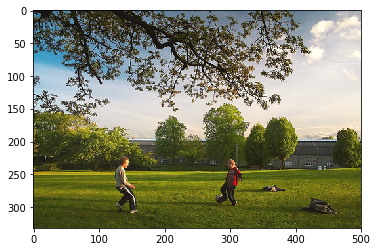

```
Greedy: two children play on the grass
```

```python
pic = list(encoding_test.keys())[3]
image_load = encoding_test[pic].reshape((1,2048))
x=plt.imread(images+pic)
plt.imshow(x)
plt.show()
print("Greedy:",greedySearch(image_load))
```

```python
def return_captions(img_path):
    temp = preprocess(img_path)
    x=plt.imread(img_path)
    plt.imshow(x)
    plt.show()
    fea_vec = model_new.predict(temp) # Get the encoding vector for the image
    fea_vec = np.reshape(fea_vec, (1,2048)) # reshape from (1, 2048) to (2048, )
    print("Caption: ",greedySearch(fea_vec).title())
```

```python
img_path = [i for i in os.listdir('test_images')]
```

[figure not shown]

```
Caption:  Race Car Is Driving Through The Snow
```

[figure not shown]

```
Caption:  Man In Red Shirt Is Walking On The Beach
```

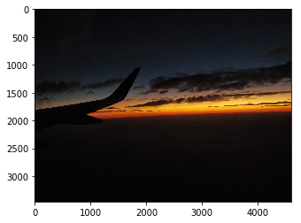

```
Caption:  The White Dog Is Walking Through The Water
```

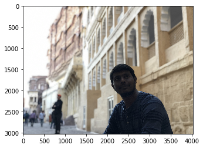

```
Caption:  Man In Black Shirt Is Standing Outside Of Building
```

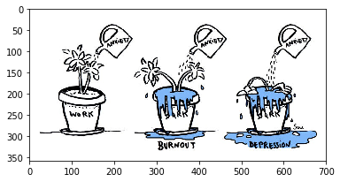

```
Caption:  Man In Black Shirt Is Standing Next To Woman In Red Shirt
```

```python
for i in img_path:
    return_captions("test_images/{}".format(i))
```

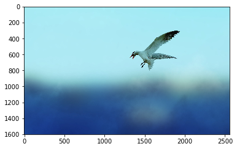

```
Caption:  Man In Red Shirt Is Standing On The Edge Of The Ocean With His Arms Out
```

```python
return_captions("test_images/birds-flying-in-the-sky-wallpaper-1.jpg")
```

Image 1 : I took this one from the internet, the output is beyond my expectations!

Image 2 :The camel in the background is wearing a red sleeve, and a man is walking on the sand, this is a decent output. Again I cannot get the model to concentrate on me!

Image 3 : That was an image taken from a flight, but the model does not seem to understand the sky, airplane or the clouds, interesting.

Image 4: looks like the model concentrated on the man standing behind me, that is amazing, given the image itself was taken in portrait mode and the man is faded out! I cannot explain why the image did not pay attention to me though!

Image 5: I wanted to try this image, the model does not seem to understand anything in this image.

For a model that was trained for 8 epochs, the output produced is very promising.